# Analysis of Directional Data

# Introduction

## Examples

Wish to analyze data in which response is a “direction”:

- 2d directional data are called circular data
- 3d directional data are called spherical data
- not all “directional” data are directions in the usual sense
- “directional” data may also arise in higher dimensions

## Wind Directions

- Recorded at Col de la Roa, Italian Alps
- n = 310 (first 40 listed below)
- Radians, clockwise from north
- Source: Agostinelli (CSDA 2007); also R package circular

## Data

```
## |===================================
## | 6.23 | 1.03 | 0.15 | 0.72 | 2.20
## | 0.46 | 0.63 | 1.45 | 0.37 | 1.95
## | 0.08 | 0.15 | 0.33 | 0.09 | 0.09
## | 6.23 | 0.05 | 6.14 | 6.28 | 6.17
## | 6.24 | 6.02 | 6.14 | 6.25 | 0.01
## | 5.38 | 5.30 | 5.63 | 0.77 | 1.34
## | 6.14 | 0.22 | 6.23 | 2.33 | 3.61
## | 0.49 | 6.12 | 0.01 | 0.00 | 0.46
## |===================================
```

## Plot

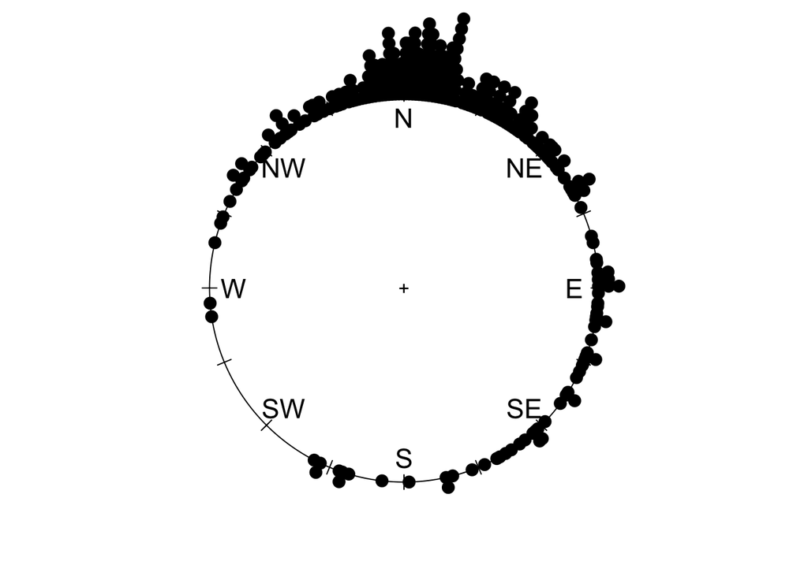

## Arrival Times at an ICU

- 24-hour clock times (format hrs.mins)
- n = 254 (first 32 listed below)
- Source: Cox & Lewis (1966); also Fisher (1993) and R package circular

## Data

```
## |================================
## | 11.00 | 17.00 | 23.15 | 10.00
## | 12.00 | 8.45  | 16.00 | 10.00
## | 15.30 | 20.20 | 4.00  | 12.00
## | 2.20  | 12.00 | 5.30  | 7.30
## | 12.00 | 16.00 | 16.00 | 1.30
## | 11.05 | 16.00 | 19.00 | 17.45
## | 20.20 | 21.00 | 12.00 | 12.00
## | 18.00 | 22.00 | 22.00 | 22.05
## |================================
```

## Plot

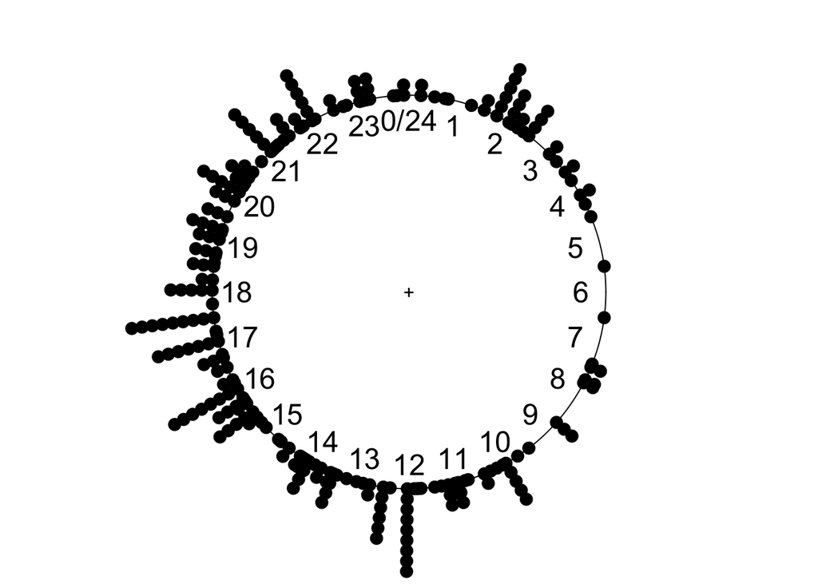

## Primate Vertebrae

- Orientation of left superior facet of last lumbar vertebra in humans, gorillas, and chimpanzees
- Source: Keifer (2005 UF Anthropology MA Thesis)

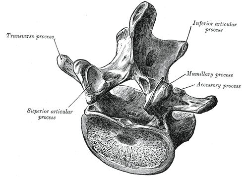

## Plot of Human Data

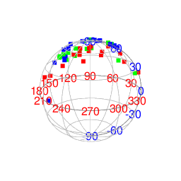

## Butterfly Migrations

- Direction of travel observed for 2649 migrating butterflies in Florida
- Source: Thomas J Walker, University of Florida, Dept of Entomology and Nematology
- Other variables:
  - site: 23 locations in Florida
  - observer: Thomas Walker (tw) or James J. Whitesell (jw)
  - species: cloudless sulphur (cs), gulf fritillary (gf), long-tailed skipper (lt)
  - distance to coast (km)
  - date and time of observation
  - percentage of sky free of clouds
  - quality of sunlight: (b)right, (h)aze, (o)bstructed, (p)artly obstructed
  - presence/absence and direction (N, NE, E, SE, S, SW, W, NW) of wind
  - temperature

## Why is the Analysis of Directional Data Different?

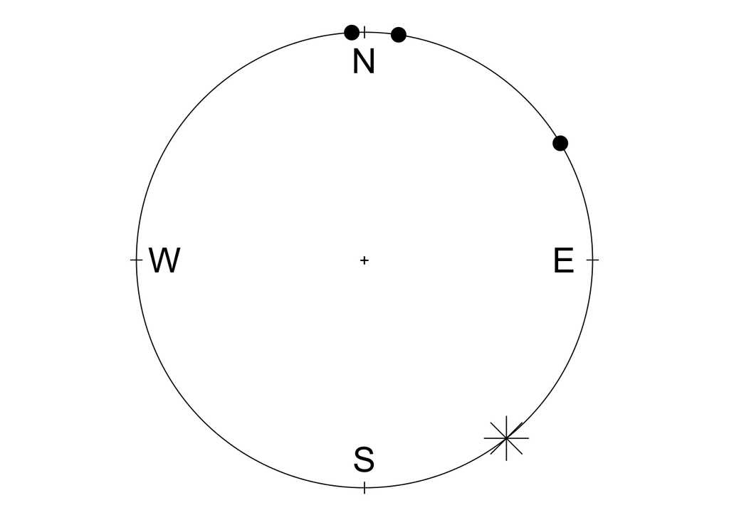

# Graphical Display of Directional Data

## Graphical Display of Circular Data (in R)

- Have already seen simple dot plots for circular data, e.g., for the wind data:

```r
windc <- circular(wind, type = "angles", units = "radians",
                  template = "geographics")
require("circular")
par(mar=c(0,0,0,0)+0.1, oma=c(0,0,0,0)+0.1)
plot(windc, cex=1.5, axes=FALSE,
     bin=360, stack=TRUE, sep=0.035, shrink=1.3)
axis.circular(at=circular(seq(0, (7/4)*pi, pi/4),
                  template="geographics"),
              labels=c("N","NE","E","SE","S","SW","W","NW"),
              cex=1.4)
ticks.circular(circular(seq(0, (15/8)*pi, pi/8)),
               zero=pi/2, rotation="clock",
               tcl=0.075)
```

## Graphical Display of Circular Data (in R) (ctd)

- and for the ICU data:

```r
## Note that pch=17 does not work properly here.
par(mar=c(0,0,0,0)+0.1, oma=c(0,0,0,0)+0.1)
plot(fisherB1c, cex=1.5, axes=TRUE,
     bin=360, stack=TRUE, sep=0.035, shrink=1.3)
```

- and one more …

## Graphical Display of Circular Data (in R) (ctd)

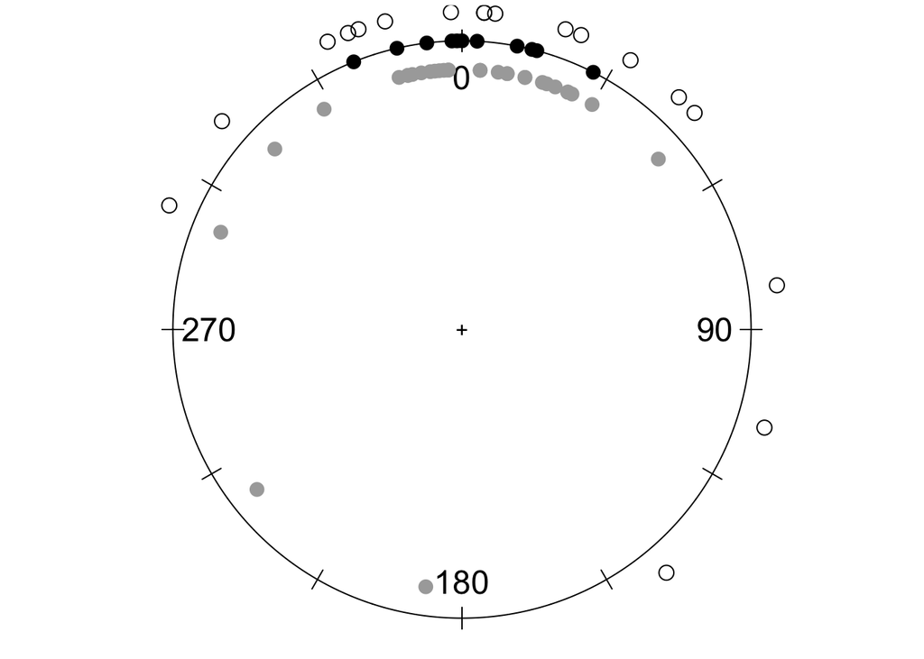

## Graphical Display of Circular Data (in R) (ctd)

```r
par(mar=c(0,0,0,0)+0.1, oma=c(0,0,0,0)+0.1)
plot(fisherB10c$set1, units="degrees", zero=pi/2,
     rotation="clock", pch=16, cex=1.5)
ticks.circular(circular(seq(0, (11/6)*pi, pi/6)),
               zero=pi/2, rotation="clock", tcl=0.075)
points(fisherB10c$set2, zero=pi/2,
       rotation="clock", pch=16, col="darkgrey",
       next.points=-0.1, cex=1.5)
points(fisherB10c$set3, zero=pi/2,
       rotation="clock", pch=1,
       next.points=0.1, cex=1.5)
```

## Circular Histograms

- Circular histograms exist (see Fisher and Mardia and Jupp) but is there a ready-made function in R?

## Rose Diagrams

- Invented by Florence Nightingale (elected first female member of the Royals Statistical Society in 1859; honorary member of ASA)
- Nightingale’s rose in R (see also this post and the R graph catalog)
- Note that radii of segments are proportional to square root of the frequencies (counts), so that areas are proportional to frequencies. Is this the right thing to do?
- Rose diagrams suffer from the same problems as histograms. The impression conveyed may depend strongly on:
  - the binwidth of the cells
  - the choice of starting point for the bins

## Adding a Rose Diagram to the Plot of Wind Directions

```r
rose.diag(windc, bins=16, col="darkgrey",
          cex=1.5, prop=1.35, add=TRUE)
```

## Adding a Rose Diagram to the Plot of Wind Directions

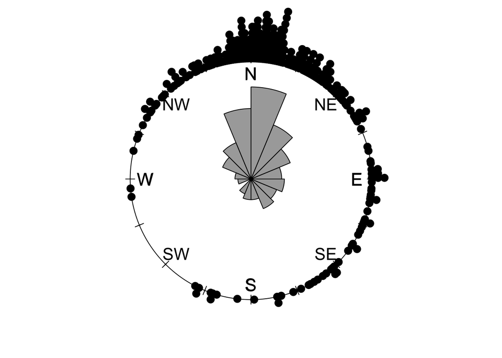

## Changing the Binwidth

### Fewer/Wider Bins

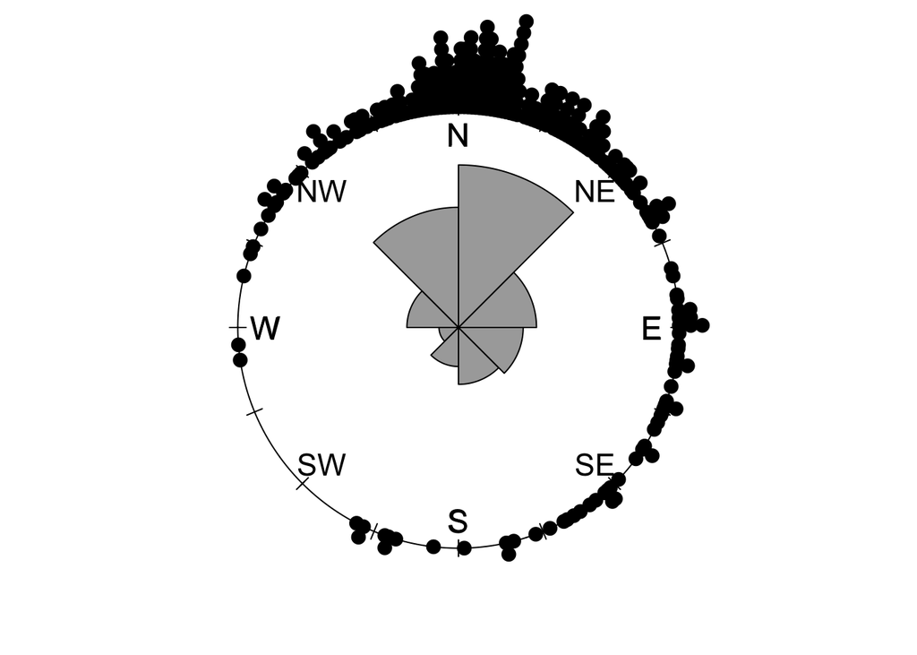

### Narrow Bins

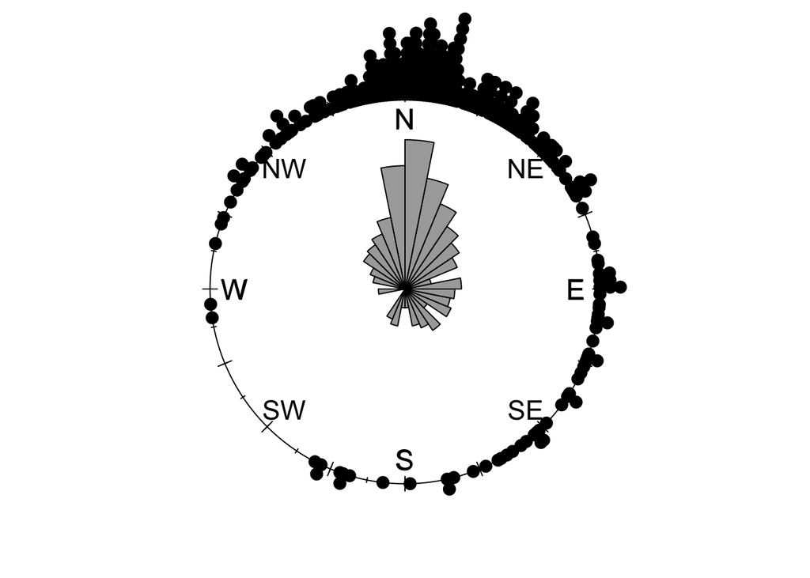

## Changing the Radii

```r
rose.diag(windc, bins=16, col="darkgrey",
          radii.scale="linear",
          cex=1.5, prop=2.4, add=TRUE)
```

## Changing the Radii

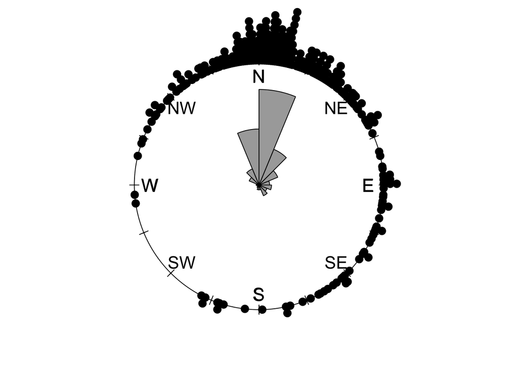

## Kernel Density Estimates

```r
lines(density.circular(windc, bw=40), lwd=2, lty=1)
```

## Kernel Density Estimates

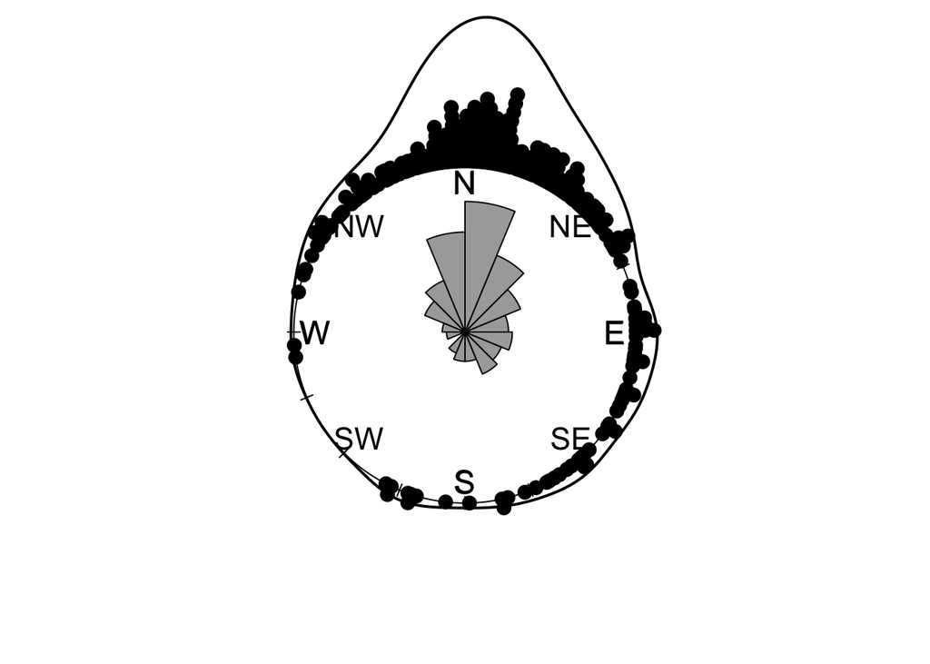

## Spherical Data

- Are there any canned routines for plotting spherical data in R?

# Basic Summary Statistics

## Mean Direction and Mean Resultant Length

- First three observations from the wind directions data:

```
## |=======================
## | theta | x     | y
## | 6.23  | -0.06 | 1.00
## | 1.03  | 0.86  | 0.51
## | 0.15  | 0.15  | 0.99
## |=======================
```

- resultant (sum of direction vectors): (0.952, 2.5)
- mean vector: $(\bar{x}, \bar{y}) =$ (0.317, 0.833)
- resultant length (Euclidean norm of resultant): R = 2.675
- mean resultant length: $\bar{R} =$ 0.892}
- mean direction: $(\bar{x}, \bar{y})/\bar{R} =$ (0.356, 0.934)
- $\tilde{\theta} =$ 0.364

## Plot

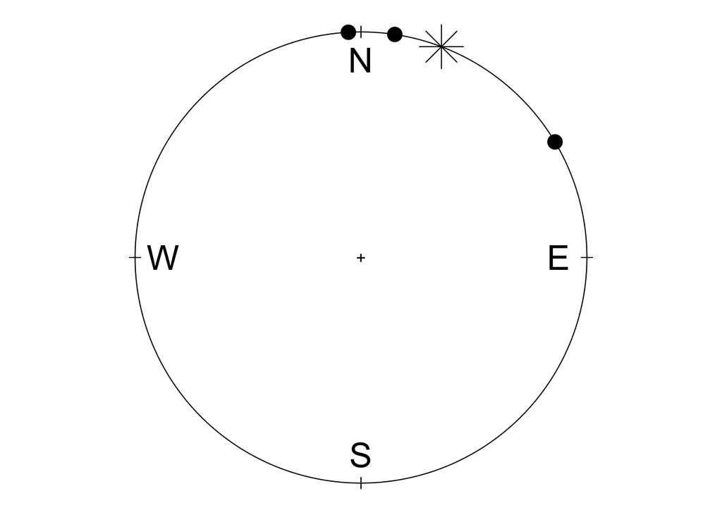

# Aside: Generating from the Uniform Distribution on the Sphere

## Generating Random Points on the Sphere

- Wish to generate a random “direction” in d-dimensions; i.e., an observation from the uniform distribution in the $d-1$ sphere.
- Usual way: let X ~ $\mbox{N}_d$(0, I) and return U = X/||X||.
- An alternative rejection sampler:
  - Repeat until ||X|| <= 1
    - Let X be uniformly distributed on the cube [-1,1]<sup>d</sup>
  - Return U = X/||X||
- What is the acceptance rate for the rejection sampler:
  - Volume of the $d - 1$ sphere is $\pi^{d/2}/\Gamma(d/2 + 1)$
  - Volume of [-1,1]<sup>d</sup> is 2<sup>d</sup>
  - Acceptance rate is $(\pi^{1/2}/2)^d/\Gamma(d/2 + 1)$
  - Curse of dimensionality

```
## |===========================================================
## | dimension       | 2  | 3  | 4  | 5  | 6 | 7 | 8 | 9 | 10
## | accept rate (%) | 79 | 52 | 31 | 16 | 8 | 4 | 2 | 1 | 0
## |===========================================================
```

```r
runifSphere <- function(n, dimension, method=c("norm", "cube", "slownorm")) {
    method <- match.arg(method)
    if (method=="norm") {
        u <- matrix(rnorm(n*dimension), ncol=dimension)
        u <- sweep(u, 1, sqrt(apply(u*u, 1, sum)), "/")
    } else if (method=="slownorm") {
        u <- matrix(nrow=n, ncol=dimension)
        for (i in 1:n) {
            x <- rnorm(dimension)
            xnorm <- sqrt(sum(x^2))
            u[i,] <- x/xnorm
        }
    } else {
        u <- matrix(nrow=n, ncol=dimension)
        for (i in 1:n) {
            x <- runif(dimension, -1, 1)
            xnorm <- sqrt(sum(x^2))
            while (xnorm > 1) {
                x <- runif(dimension, -1, 1)
                xnorm <- sqrt(sum(x^2))
            }
            u[i,] <- x/xnorm
        }
    }
    u
}
```

## Easy fix for Borel’s paradox in 3-d

Take longitude $\phi \sim U(0,2\pi)$ independent of latitude $\theta = \arcsin(2U-1)$, $U \sim U(0,1)$.

# Rotationally Symmetric Distributions

## Comparison of Projected Normal and Langevin Distributions

One way that we might compare the $\mbox{L}(\mu, \kappa)$ and $\mbox{PN}(\gamma\mu, I)$ distributions by choosing $\kappa$ and $\gamma$ to give the same mean resultant lengths and comparing the densities of the cosine of the angle $\theta$ between $U$ and $\mu$.

Of course matching mean resultant lengths is not necessarily the best way to compare these families of distributions.

### $d = 2$

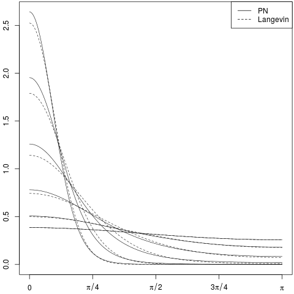

### $d = 3$

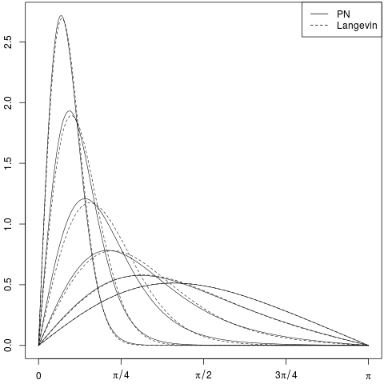

### $d = 4$

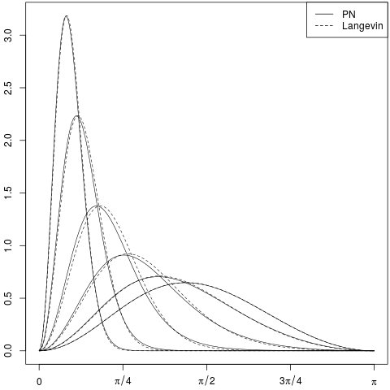